# Assignment Problem 1

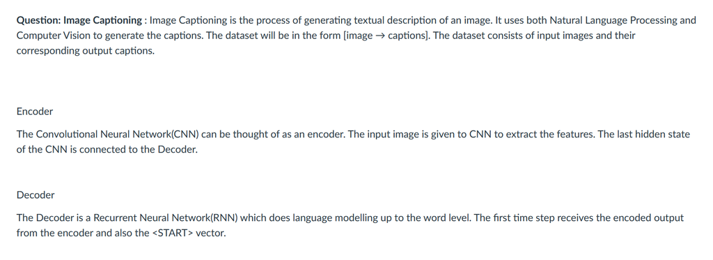

## Part 1 : Importing Libraries/Dataset

```
1) Importing the libraries
2) Importing the dataset
```

```python
import tensorflow as tf
from tensorflow import keras
import matplotlib.pyplot as plt
from tensorflow.keras.applications import ResNet50
from tensorflow.keras.models import Model
from tensorflow.keras.preprocessing.sequence import pad_sequences
from tensorflow.keras.utils import to_categorical
import numpy as np
from numpy import array
import pandas as pd
import cv2
from glob import glob
import PIL
import time
from tqdm import tqdm
import os
import pickle

from tensorflow.keras.models import load_model
from time import process_time
```

```python
path_to_img = "dataset/images/"
images = glob(path_to_img + "*.jpg")
len(images)
```

```
8091
```

## Part 2 : Data processing

```
1) Reading the pickle file converting it into the format needed for Ml model
2) Plot at least two samples and their captions (use matplotlib/seaborn/any other library).
3) Preprocssing of Image captions and storing everything into a new "captions.txt" file.
```

```python
#Loading the pickle file using pandas
pckl_file = pd.read_pickle("pickle_file.pkl")
print(pckl_file[:5])
```

```
['318667317_108c402140.jpg#4\tA man in a black hoodie be hold a paper sign .', '2072574835_febf0c5fb9.jpg#4\tThree race dog be run out of the start gate on a track .', '3083016677_5782bc337c.jpg#4\tTwo motorcycle with two rider each .', '95734038_2ab5783da7.jpg#0\tA man on a bike nest to a river .',…
```

We are going to create a dicitonary for the captions. The dictionary key will be the image name and the dictionary values will be the list of captions.

```python
# Fucntion to create dictionary from pickle file
def creating_dict(caption_list):
    caption_dict = dict()
    for i in caption_list:
        temp=i.split("\t")
        img_name, img_caption = temp[0][:-2], temp[1]
        temp2=img_name.split(".")
        img_name=temp2[0]

        # Create dictionary
        if img_name not in caption_dict:
            caption_dict[img_name] = list()
        caption_dict[img_name].append(img_caption)
    return(caption_dict)
```

```python
data=creating_dict(pckl_file)
print(len(data))
```

```
8037
```

```python
#printing first 5 keys of the dictionary
list(data.keys())[:5]
```

```
['318667317_108c402140',
 '2072574835_febf0c5fb9',
 '3083016677_5782bc337c',
 '95734038_2ab5783da7',
 '241346146_f27759296d']
```

```python
#printing the values of the first key in the dictionary
data['318667317_108c402140']
```

```
['A man in a black hoodie be hold a paper sign .',
 'A homeless man carry a sign that say " hungry " .',
 'A bearded man hold a sign .',
 'A man in a black hoodie hold a small sign .']
```

Ploting 4 samples and their captions

```
Captions :  ['A white dog shake on the edge of a beach with an orange ball .', 'Dog with orange ball at feet , stand on shore shake off water', 'White dog with brown ear stand near water with head turn to one side .']
```

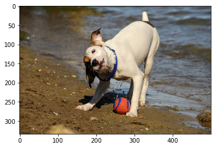

```python
i=7
plt.figure()
image = cv2.imread(images[i])
image = cv2.cvtColor(image, cv2.COLOR_BGR2RGB)
plt.imshow(image)
print("Captions : ",data[images[i].split(".")[0].split("\\")[1]])
```

```
Captions :  ['A man and woman care for an infant along the side of a body of water .']
```

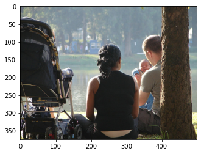

```python
i=17
plt.figure()
image = cv2.imread(images[i])
image = cv2.cvtColor(image, cv2.COLOR_BGR2RGB)
plt.imshow(image)
print("Captions : ",data[images[i].split(".")[0].split("\\")[1]])
```

```
Captions :  ['Two person stand outside a blue tent structure on a snowy surface .', 'Two man be about to enter an ice fish tent on a snow cover lake .', 'two man set up a blue ice fish hut on an iced over lake', 'Two man , stand on an ice , look into something cover with a blue tarp .']
```

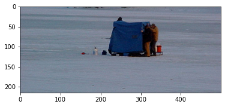

```python
i=27
plt.figure()
image = cv2.imread(images[i])
image = cv2.cvtColor(image, cv2.COLOR_BGR2RGB)
plt.imshow(image)
print("Captions : ",data[images[i].split(".")[0].split("\\")[1]])
```

```
Captions :  ['A woman paddle a boat down a river .', 'A woman kayak down a river .', 'A woman with a paddle .']
```

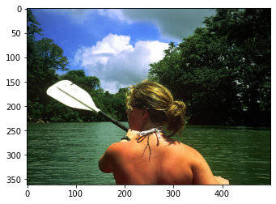

```python
i=37
plt.figure()
image = cv2.imread(images[i])
image = cv2.cvtColor(image, cv2.COLOR_BGR2RGB)
plt.imshow(image)
print("Captions : ",data[images[i].split(".")[0].split("\\")[1]])
```

Image caption preprocessing:

The below function is for the following purposes:

```
*) Making sure all the words in each of the sentences are converted to a lower case to avoid duplication.
*) Removing words with a length of less than two --> removing single letters and punctuations
```

```python
def cleaning(data):
    dict_2 = dict()
    for key, value in data.items():
        for i in range(len(value)):
            lines = ""
            line1 = value[i]
            for j in line1.split():
                if len(j) < 2:
                    continue
                j = j.lower()
                lines += j + " "
            if key not in dict_2:
                dict_2[key] = list()

            dict_2[key].append(lines)

    return dict_2
```

```python
data2 = cleaning(data)
print(len(data2))
```

```
8037
```

```python
#Creating a vocabulary of the words and calculate the total number of unique entities present.
vocabulary_data= set()
for key in data2.keys():
    [vocabulary_data.update(d.split()) for d in data2[key]]
print(len(vocabulary_data))
```

```
5531
```

```python
#saving all the preprocessing done above to a text file for further purposes.
def creating_text(data2, filename):
    lines = list()
    for key, value in data2.items():
        for desc in value:
            lines.append(key + ' ' + desc)
    data = '\n'.join(lines)
    file = open(filename, 'w')
    file.write(data)
    file.close()

creating_text(data2, 'captions.txt')
```

A sample of the text file created above.

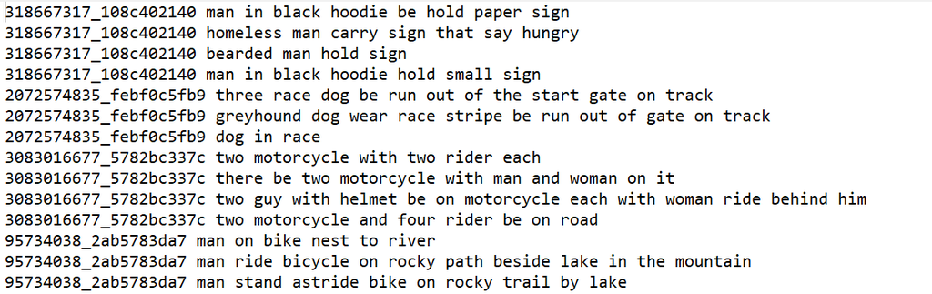

## Part 3: Model Building

This module consists of following parts:

```
1) Preprocessing of images into the necessary format of Resnet50. (Specified in the requirements).
2) Inputing the resnet50 model.
3) Saving all preprocessed data into a pickle file for further actions.
```

```python
images = 'dataset/images/'
img = glob(images + '*.jpg')
print(len(img))

def preprocess(image_path):
    # Convert all the images to size 224*224 as expected by the resnet50 model
    img = tf.keras.preprocessing.image.load_img(image_path, target_size=(224, 224))
    # Convert PIL image to numpy array of 3-dimensions
    x = tf.keras.preprocessing.image.img_to_array(img)
    # Add one more dimension
    x = np.expand_dims(x, axis=0)
    # pre-process the images using preprocess_input() from resnet module
    x = tf.keras.applications.resnet50.preprocess_input(x)
    return x
```

```
8091
```

```python
# Load the resnet50 model
input1 = ResNet50(weights='imagenet')

# Create a new model, by removing the last layer (output layer) from the inception v3
model = Model(input1.input, input1.layers[-2].output)

model.summary()
```

```
Model: "model"
__________________________________________________________________________________________________
 Layer (type)                   Output Shape         Param #     Connected to
==================================================================================================
 input_1 (InputLayer)           [(None, 224, 224, 3  0           []
                                )]

 conv1_pad (ZeroPadding2D)      (None, 230, 230, 3)  0           ['input_1[0][0]']

 conv1_conv (Conv2D)            (None, 112, 112, 64  9472        ['conv1_pad[0][0]']
                                )

 conv1_bn (BatchNormalization)  (None, 112, 112, 64  256         ['conv1_conv[0][0]']
                                )

 conv1_relu (Activation)        (None, 112, 112, 64  0           ['conv1_bn[0][0]']
                                )

 pool1_pad (ZeroPadding2D)      (None, 114, 114, 64  0           ['conv1_relu[0][0]']
                                )

 pool1_pool (MaxPooling2D)      (None, 56, 56, 64)   0           ['pool1_pad[0][0]']

 conv2_block1_1_conv (Conv2D)   (None, 56, 56, 64)   4160        ['pool1_pool[0][0]']

 conv2_block1_1_bn (BatchNormal  (None, 56, 56, 64)  256         ['conv2_block1_1_conv[0][0]']
 ization)

 conv2_block1_1_relu (Activatio  (None, 56, 56, 64)  0           ['conv2_block1_1_bn[0][0]']
 n)

 conv2_block1_2_conv (Conv2D)   (None, 56, 56, 64)   36928       ['conv2_block1_1_relu[0][0]']

 conv2_block1_2_bn (BatchNormal  (None, 56, 56, 64)  256         ['conv2_block1_2_conv[0][0]']
 ization)

 conv2_block1_2_relu (Activatio  (None, 56, 56, 64)  0           ['conv2_block1_2_bn[0][0]']
 n)

 conv2_block1_0_conv (Conv2D)   (None, 56, 56, 256)  16640       ['pool1_pool[0][0]']
```

[output cut: 425 more lines]

```
 ization)

 conv5_block3_add (Add)         (None, 7, 7, 2048)   0           ['conv5_block2_out[0][0]',
                                                                  'conv5_block3_3_bn[0][0]']

 conv5_block3_out (Activation)  (None, 7, 7, 2048)   0           ['conv5_block3_add[0][0]']

 avg_pool (GlobalAveragePooling  (None, 2048)        0           ['conv5_block3_out[0][0]']
 2D)

==================================================================================================
Total params: 23,587,712
Trainable params: 23,534,592
Non-trainable params: 53,120
__________________________________________________________________________________________________
```

After pre-processing of the images,we are saving all this to a pickle file.This will help during prediction process. The following code block did the same

```python
# Function to encode a given image into a vector of size (2048, )
def encode(image):
    image = preprocess(image) # preprocess the image
    fea_vec = model.predict(image) # Get the encoding vector for the image
    fea_vec = np.reshape(fea_vec, fea_vec.shape[1]) # reshape from (1, 2048) to (2048, )
    return fea_vec

encoding = {}

for i in tqdm(img):
    encoding[i[len(images):]] = encode(i)

# Save the features in the images1 pickle file
with open("images1.pkl", "wb") as encoded_pickle:
    pickle.dump(encoding, encoded_pickle)
```

Below code blocks are for:

```
*) Saving all the essential files containing the information of the unique words to index.
*) All the indices linked to their respective words.
(the above process is for both the generator and the prediction stage of the model.)
*) Defining a fixed maximum length for this process for not exceeding limits.
```

```python
# Creating a list of all train captions
train_captions = []
data2.pop("2258277193_586949ec62")
for key, value in data2.items():
    for caption in value:
        train_captions.append(caption)

len(train_captions)
```

```
24996
```

```python
# WORDS which are occuring atleast 10 times are only considered
word_count_max = 10
word_counts = {}
no_of_sents = 0

for sent in train_captions:
    no_of_sents += 1
    for w in sent.split(' '):
        word_counts[w] = word_counts.get(w, 0) + 1

vocab = [w for w in word_counts if word_counts[w] >= word_count_max]
print('preprocessed words %d -> %d' % (len(word_counts), len(vocab)))
```

```
preprocessed words 5532 -> 1233
```

```python
# Converting the words to indices ,also indices to words.
ixtoword = {}
wordtoix = {}
ix = 1
for w in vocab:
    wordtoix[w] = ix
    ixtoword[ix] = w
    ix += 1
vocab_size = len(ixtoword) + 1
vocab_size

# Save the words to index and index to word as pickle files

with open("words.pkl", "wb") as encoded_pickle:
    pickle.dump(wordtoix, encoded_pickle)

with open("words1.pkl", "wb") as encoded_pickle:
    pickle.dump(ixtoword, encoded_pickle)
```

```python
# convert descriptons(cleaned) dictionary to list of descriptions
def to_lines(descriptions):
    all_desc = list()
    for key in descriptions.keys():
        [all_desc.append(d) for d in descriptions[key]]
    return all_desc

# calculate the length of the description with the most words
def max_length(descriptions):
    lines = to_lines(descriptions)
    return max(len(d.split()) for d in lines)

# determine the maximum sequence length
max_length = max_length(data2)
print('Description Length: %d' % max_length)
```

```
Description Length: 29
```

Creating the data generator:

Each image is converted into its respective feature length, and all the descriptions are padded so that it has to be passed through an LSTM network for future word prediciton.

```python
# data generator
def data_generator(descriptions, photos, wordtoix, max_length, num_photos_per_batch):
    X1, X2, y = list(), list(), list()
    n=0
    # loop for ever over images
    while 1:
        for key, desc_list in descriptions.items():
            n+=1
            if key =="2258277193_586949ec62":
                print(key)
                continue
            # retrieve the photo feature
            photo = photos[key+'.jpg']
            for desc in desc_list:
                # encode the sequence
                seq = [wordtoix[word] for word in desc.split(' ') if word in wordtoix]
                # split one sequence into multiple X, y pairs
                for i in range(1, len(seq)):
                    # split into input and output pair
                    in_seq, out_seq = seq[:i], seq[i]
                    # pad input sequence
                    in_seq = pad_sequences([in_seq], maxlen=max_length)[0]
                    # encode output sequence
                    out_seq = to_categorical([out_seq], num_classes=vocab_size)[0]
                    # store
                    X1.append(photo)
                    X2.append(in_seq)
                    y.append(out_seq)
            # yield the batch data
            if n==num_photos_per_batch:
                yield ([array(X1), array(X2)], array(y))
                X1, X2, y = list(), list(), list()
                n=0
```

Creating word embedding vectors for each unique word for a fixed length is done using pre-trained glove.6B.200d.txt . The word embedding method is used to map every single index of words to a 200 length vector to make it an uniformly sized distribution. The following code block does the above:

#### NB: For the below code to work "glove.6B.200d.txt" should be downloaded and loaded from https://github.com/stanfordnlp/GloVe

```python
embeddings_index = {}
f = open('glove.6B.200d.txt', encoding="utf-8")

for line in f:
    values = line.split()
    word = values[0]
    coefs = np.asarray(values[1:], dtype='float32')
    embeddings_index[word] = coefs
f.close()
print('Found %s word vectors.' % len(embeddings_index))

embedding_dim = 200

# Get 200-dim dense vector for each of the 10000 words in our vocabulary
embedding_matrix = np.zeros((vocab_size, embedding_dim))

for word, i in wordtoix.items():
    #if i < max_words:
    embedding_vector = embeddings_index.get(word)
    if embedding_vector is not None:
        # Words not found in the embedding index will be all zeros,
        embedding_matrix[i] = embedding_vector

embedding_matrix.shape
```

```
Found 400001 word vectors.
```

```
(1234, 200)
```

As per the requirements mentioned in the question model is created and trained,

[output not shown]

The image vector and the LSTM predictions are combined as one unit. This is passed through some dense layers and then to a SoftMax activation function, which is equivalent to the size of the pre-defined vocabulary.

```python
from tensorflow.keras.layers import Dense, Input, Conv2D, MaxPool2D, LSTM, add
from tensorflow.keras.layers import Activation, Dropout, Flatten, Embedding
from tensorflow.keras.models import Model
from keras.regularizers import l1

inputs1 = Input(shape=(2048,))
fe1 = Dropout(0.4)(inputs1)
fe2 = Dense(256, activation='relu')(fe1)

inputs2 = Input(shape=(max_length,))
se1 = Embedding(vocab_size, embedding_dim, mask_zero=True)(inputs2)
se2 = LSTM(12,return_sequences=True,recurrent_regularizer=l1(0.05))(se1)
se3 = LSTM(24,return_sequences=True,recurrent_regularizer=l1(0.05))(se2)
se4 = LSTM(48,return_sequences=True,recurrent_regularizer=l1(0.05))(se3)
se5 = LSTM(128,return_sequences=True,recurrent_regularizer=l1(0.05))(se4)
se6 = Dropout(0.4)(se5)
se7 = LSTM(256,recurrent_regularizer=l1(0.05))(se6)

decoder1 = add([fe2, se7])
decoder2 = Dense(1000, activation='relu')(decoder1)
outputs = Dense(vocab_size, activation='softmax')(decoder2)

model = Model(inputs=[inputs1, inputs2], outputs=outputs)

#printing model summary
model.summary()
```

```
Model: "model_1"
__________________________________________________________________________________________________
 Layer (type)                   Output Shape         Param #     Connected to
==================================================================================================
 input_3 (InputLayer)           [(None, 29)]         0           []

 embedding (Embedding)          (None, 29, 200)      246800      ['input_3[0][0]']

 lstm (LSTM)                    (None, 29, 12)       10224       ['embedding[0][0]']

 lstm_1 (LSTM)                  (None, 29, 24)       3552        ['lstm[0][0]']

 lstm_2 (LSTM)                  (None, 29, 48)       14016       ['lstm_1[0][0]']

 input_2 (InputLayer)           [(None, 2048)]       0           []

 lstm_3 (LSTM)                  (None, 29, 128)      90624       ['lstm_2[0][0]']

 dropout (Dropout)              (None, 2048)         0           ['input_2[0][0]']

 dropout_1 (Dropout)            (None, 29, 128)      0           ['lstm_3[0][0]']

 dense (Dense)                  (None, 256)          524544      ['dropout[0][0]']

 lstm_4 (LSTM)                  (None, 256)          394240      ['dropout_1[0][0]']

 add (Add)                      (None, 256)          0           ['dense[0][0]',
                                                                  'lstm_4[0][0]']

 dense_1 (Dense)                (None, 1000)         257000      ['add[0][0]']

 dense_2 (Dense)                (None, 1234)         1235234     ['dense_1[0][0]']

==================================================================================================
Total params: 2,776,234
Trainable params: 2,776,234
Non-trainable params: 0
__________________________________________________________________________________________________
```

```python
model.layers[1]
```

```
<keras.layers.embeddings.Embedding at 0x1e35e820430>
```

Reasons for choosing adam as optimizer

It adds to the advantages of Adadelta and RMSprop, the storing of an exponentially decaying average of past gradients similar to momentum.

```
*) Adam is the best among the adaptive optimizers in most of the cases.
*) Good with sparse data: the adaptive learning rate is perfect for this type of datasets.
*) There is no need to focus on the learning rate value. hence default learning rate of ADAM is used
```

```python
model.layers[1].set_weights([embedding_matrix])
model.layers[1].trainable = False

model.compile(loss='categorical_crossentropy', optimizer='adam')
#Running for 10 epochs
epochs = 10
number_pics_per_bath = 3
steps = len(data2)//number_pics_per_bath

features = pickle.load(open("images1.pkl", "rb"))
tf.config.run_functions_eagerly(True)
t1_start=process_time()
#Model is saved after each epoch to save valuable training time and also incase of overfitting
generator = data_generator(data2, features, wordtoix, max_length, number_pics_per_bath)
history=model.fit(generator, epochs=epochs, steps_per_epoch=steps,verbose=1)
t1_stop=process_time()
model.save('model_final.h5')
```

```python
print("Time Taken for training (seconds): ",round((t1_stop-t1_start),6))
```

```
Time Taken for training (seconds):  30680.046875
```

```python
model1_loss=history.history['loss'][-1]
```

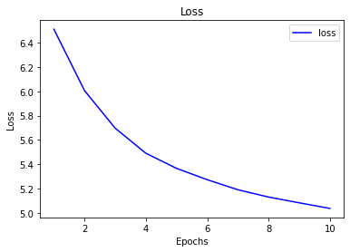

```python
#Graph of loss
history_dict = history.history
history_dict.keys()

loss = history_dict['loss']

epochs = range(1, len(loss) + 1)

# "bo" is for "blue dot"
plt.plot(epochs, loss, 'b', label='loss')
# b is for "solid blue line"
plt.title('Loss')
plt.xlabel('Epochs')
plt.ylabel('Loss')
plt.legend()

plt.show()
```

## Part 4: Model Evaluation

Taking a random image and predicitng its caption.

Loading all the presaved pickle files as well as the model. This is entirely independent from the model building. so that can be done independently at any time

```python
features = pickle.load(open("images1.pkl", "rb"))
model = load_model('model_final.h5')
images = "dataset/images/"
max_length = 33
words_to_index = pickle.load(open("words.pkl", "rb"))
index_to_words = pickle.load(open("words1.pkl", "rb"))
```

The below function,

```
*)Load the images
*)Load those image vectors
*)Create word embedding
*) use the saved model for making the appropriate predictions.
```

```python
def predicting_the_caption(picture):
    in_text = 'startseq'
    for i in range(max_length):
        sequence = [words_to_index[w] for w in in_text.split() if w in words_to_index]
        sequence = pad_sequences([sequence], maxlen=29)
        yhat = model.predict([picture,sequence], verbose=0)
        yhat = np.argmax(yhat)
        word = index_to_words[yhat]
        in_text += ' ' + word
        if word == 'endseq':
            break
    final = in_text.split()
    final = final[1:-1]
    final = ' '.join(final)
    return final
```

Loading 2 random images and predicting their caption

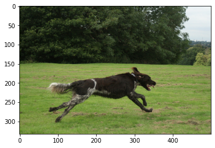

```
Caption: dog run through the
```

```python
pic_no = 297
picture = list(features.keys())[pic_no]
image = features[picture].reshape((1,2048))
x = plt.imread(images+picture)
plt.imshow(x)
plt.show()
print("Caption:", predicting_the_caption(image))
```

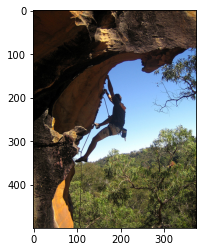

```
Caption: rock climber be climb on
```

```python
pic_no = 351
picture = list(features.keys())[pic_no]
image = features[picture].reshape((1,2048))
x = plt.imread(images+picture)
plt.imshow(x)
plt.show()
print("Caption:", predicting_the_caption(image))
```